# L08 Relational Data

Data Science 1 with R (STAT 301-1)

Author

Ryan Nguyen

## Overview

The goal of this lab is to learn and understand the concepts of **relational data**. It is extremely rare that data analyses involve one all-encompassing dataset; we usually want to combine information from multiple data tables/sources to answer interesting questions. The collection of data tables/sources is called **relational data** because it is the relations connecting the datasets together that are important.

See [two-table verbs in `dplyr`](https://dplyr.tidyverse.org/reference/index.html#two-table-verbs) for more information concerning relational data.

[Relational Database Wikipedia Page](https://en.wikipedia.org/wiki/Relational_database)

## Load Packages

```r
# Loading package(s)
library(tidyverse, quietly = T)
library(nycflights13)
library(Lahman)
library(babynames)
library(nasaweather)
library(fueleconomy)
```

## Datasets

All datasets are found within R packages, which students should be able to identify and download as needed.

## Exercises

### Exercise 1

Consider the tables/datasets contained in `nycflights13`. Imagine you wanted to draw (approximately) the route each plane flies from its origin to its destination. What variables would you need? What tables would you need to combine?

**ANSWER:** The variables we would need are origin and dest, along with lon and lat. The tables we would need to combine are `airports` and `flights`.

### Exercise 2

A relationship between `weather` and `airports` is possible. What is the relationship and how would it appear in a diagram (i.e., which variables should be matched)?

**ANSWER:** `weather` connects to `flights`, through the variables origin, year, month, day, and hour. The origin/dest variables then connects to `airports` through the variable, `faa`.

### Exercise 3

Add a surrogate key to `flights`.

```r
flights %>%
  mutate(flight_id = row_number())
```

```
# A tibble: 336,776 × 20
    year month   day dep_time sched_de…¹ dep_d…² arr_t…³ sched…⁴ arr_d…⁵ carrier
   <int> <int> <int>    <int>      <int>   <dbl>   <int>   <int>   <dbl> <chr>
 1  2013     1     1      517        515       2     830     819      11 UA
 2  2013     1     1      533        529       4     850     830      20 UA
 3  2013     1     1      542        540       2     923     850      33 AA
 4  2013     1     1      544        545      -1    1004    1022     -18 B6
 5  2013     1     1      554        600      -6     812     837     -25 DL
 6  2013     1     1      554        558      -4     740     728      12 UA
 7  2013     1     1      555        600      -5     913     854      19 B6
 8  2013     1     1      557        600      -3     709     723     -14 EV
 9  2013     1     1      557        600      -3     838     846      -8 B6
10  2013     1     1      558        600      -2     753     745       8 AA
# … with 336,766 more rows, 10 more variables: flight <int>, tailnum <chr>,
#   origin <chr>, dest <chr>, air_time <dbl>, distance <dbl>, hour <dbl>,
#   minute <dbl>, time_hour <dttm>, flight_id <int>, and abbreviated variable
#   names ¹sched_dep_time, ²dep_delay, ³arr_time, ⁴sched_arr_time, ⁵arr_delay
```

### Exercise 4

For each of the following datasets, identify any key column[s] and specify whether they are primary or foreign keys. You might need to install some packages and read some documentation.

- `Lahman::Batting,`
- `babynames::babynames`
- `nasaweather::atmos`
- `fueleconomy::vehicles`
- `ggplot2::diamonds`

**ANSWER:**

| ID | Dataset | key type |
| --- | --- | --- |
| playerID | Batting | foreign (primary in `People` dataset) |
| teamID | Batting | foreign (primary in `Teams` dataset) |
| no keys | babynames |  |
| no keys | atmos | (if we merge lat, long, year, month this could uniquely identify an observation) |
| id | vehicles | primary |
| model | vehicles | foreign (primary in `common` dataset) |

### Exercise 5

Is there a relationship between the age of a plane and its average arrival delay?

```r
age_delay <- flights %>%
  left_join(planes,
            by = c('tailnum')) %>%
  group_by(tailnum) %>%
  mutate(age = year.x - year.y) %>%
  filter(!is.na(age)) %>%
  summarize(age = mean(age, na.rm = TRUE),
            mean_arr_delay = mean(arr_delay, na.rm = TRUE))

age_delay %>%
  ungroup() %>%
  select(age, mean_arr_delay) %>%
  cor(use = "complete.obs")
```

```
                       age mean_arr_delay
age             1.00000000    -0.01639459
mean_arr_delay -0.01639459     1.00000000
```

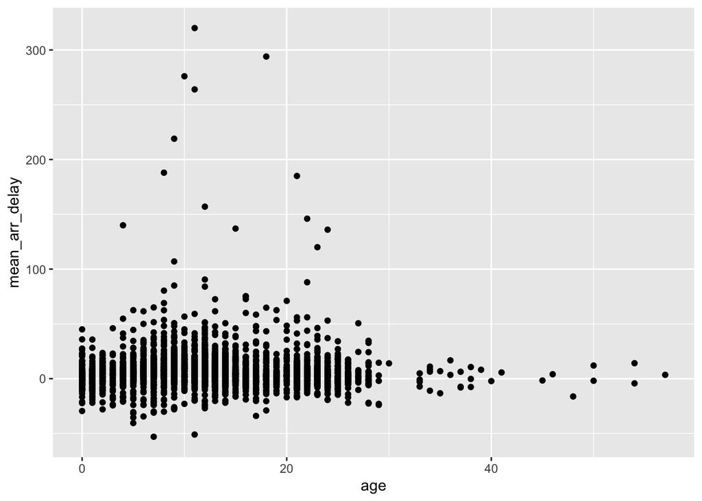

```r
age_delay %>%
  ggplot(aes(x = age, y = mean_arr_delay)) +
  geom_point()
```

**ANSWER:** While one would expect there to be a relationship between the age of a plane and the average arrival date, the fact that the correlation value is -0.016 shows us that there is not a strong relationship.

### Exercise 6

What weather conditions make it more likely to see a departure delay?

```r
weather_impact <- flights %>%
  left_join(weather,
            by = c('origin', 'time_hour', 'year', 'month', 'day', 'hour'))

# average daily impact. Under the assumption there is not a huge weather change on one day
weather_impact %>%
  group_by(origin, year, month, day) %>%
  summarize(mean_delay = mean(dep_delay, na.rm = TRUE),
            temp = mean(temp, na.rm = TRUE),
            dewp = mean(dewp, na.rm = TRUE),
            humid = mean(humid, na.rm = TRUE),
            wind_speed = mean(wind_speed, na.rm = TRUE),
            precip = mean(precip, na.rm = TRUE),
            visib = mean(visib, na.rm = TRUE)) %>%
  ungroup() %>%
  select(mean_delay, temp, dewp, humid, wind_speed, precip, visib) %>%
  cor(use = "complete.obs")
```

```
            mean_delay       temp       dewp      humid   wind_speed
mean_delay  1.00000000  0.1520163  0.3084639  0.4782457  0.077572233
temp        0.15201633  1.0000000  0.9226602  0.1575759 -0.252576722
dewp        0.30846387  0.9226602  1.0000000  0.5210014 -0.289067731
humid       0.47824575  0.1575759  0.5210014  1.0000000 -0.178714440
wind_speed  0.07757223 -0.2525767 -0.2890677 -0.1787144  1.000000000
precip      0.38641343  0.0359573  0.1845022  0.4328412 -0.001313516
visib      -0.39825679  0.1090167 -0.1366489 -0.6678837  0.059862057
                 precip       visib
mean_delay  0.386413431 -0.39825679
temp        0.035957299  0.10901675
dewp        0.184502154 -0.13664887
humid       0.432841241 -0.66788371
wind_speed -0.001313516  0.05986206
precip      1.000000000 -0.45870534
visib      -0.458705342  1.00000000
```

**ANSWER:** Based on the higher correlation values, lower visibilty, higher precipitation, and higher humidity make it more likely to see a departure delay.

### Exercise 7

What does it mean for a flight to have a missing `tailnum`? What do the tail numbers that don’t have a matching record in `planes` have in common? *Hint: one variable explains ~90% of the problems.*

```r
flights %>%
  filter(is.na(tailnum))
```

```
# A tibble: 2,512 × 19
    year month   day dep_time sched_de…¹ dep_d…² arr_t…³ sched…⁴ arr_d…⁵ carrier
   <int> <int> <int>    <int>      <int>   <dbl>   <int>   <int>   <dbl> <chr>
 1  2013     1     2       NA       1545      NA      NA    1910      NA AA
 2  2013     1     2       NA       1601      NA      NA    1735      NA UA
 3  2013     1     3       NA        857      NA      NA    1209      NA UA
 4  2013     1     3       NA        645      NA      NA     952      NA UA
 5  2013     1     4       NA        845      NA      NA    1015      NA 9E
 6  2013     1     4       NA       1830      NA      NA    2044      NA 9E
 7  2013     1     5       NA        840      NA      NA    1001      NA 9E
 8  2013     1     7       NA        820      NA      NA     958      NA 9E
 9  2013     1     8       NA       1645      NA      NA    1838      NA US
10  2013     1     9       NA        755      NA      NA    1012      NA 9E
# … with 2,502 more rows, 9 more variables: flight <int>, tailnum <chr>,
#   origin <chr>, dest <chr>, air_time <dbl>, distance <dbl>, hour <dbl>,
#   minute <dbl>, time_hour <dttm>, and abbreviated variable names
#   ¹sched_dep_time, ²dep_delay, ³arr_time, ⁴sched_arr_time, ⁵arr_delay
```

```r
flights %>%
  anti_join(planes, by = 'tailnum') %>%
  group_by(carrier) %>%
  summarize(n = n()) %>%
  arrange(desc(n))
```

```
# A tibble: 10 × 2
   carrier     n
   <chr>   <int>
 1 MQ      25397
 2 AA      22558
 3 UA       1693
 4 9E       1044
 5 B6        830
 6 US        699
 7 FL        187
 8 DL        110
 9 F9         50
10 WN         38
```

### Exercise 8

Filter `flights` to show only the flights of planes that flew at least 100 times.

```r
hundred_times <- flights %>%
  filter(!is.na(tailnum)) %>%
  group_by(tailnum) %>%
  mutate(n=n()) %>%
  filter(n >= 100)

hundred_times
```

```
# A tibble: 228,390 × 20
# Groups:   tailnum [1,217]
    year month   day dep_time sched_de…¹ dep_d…² arr_t…³ sched…⁴ arr_d…⁵ carrier
   <int> <int> <int>    <int>      <int>   <dbl>   <int>   <int>   <dbl> <chr>
 1  2013     1     1      517        515       2     830     819      11 UA
 2  2013     1     1      533        529       4     850     830      20 UA
 3  2013     1     1      544        545      -1    1004    1022     -18 B6
 4  2013     1     1      554        558      -4     740     728      12 UA
 5  2013     1     1      555        600      -5     913     854      19 B6
 6  2013     1     1      557        600      -3     709     723     -14 EV
 7  2013     1     1      557        600      -3     838     846      -8 B6
 8  2013     1     1      558        600      -2     849     851      -2 B6
 9  2013     1     1      558        600      -2     853     856      -3 B6
10  2013     1     1      558        600      -2     923     937     -14 UA
# … with 228,380 more rows, 10 more variables: flight <int>, tailnum <chr>,
#   origin <chr>, dest <chr>, air_time <dbl>, distance <dbl>, hour <dbl>,
#   minute <dbl>, time_hour <dttm>, n <int>, and abbreviated variable names
#   ¹sched_dep_time, ²dep_delay, ³arr_time, ⁴sched_arr_time, ⁵arr_delay
```

### Exercise 9

Combine `fueleconomy::vehicles` and `fueleconomy::common` to find the records for only the most common models.

```r
common_records <- vehicles %>%
  semi_join(common, by = c("make", "model"))

print(common_records)
```

```
# A tibble: 14,531 × 12
      id make  model    year class     trans drive   cyl displ fuel    hwy   cty
   <dbl> <chr> <chr>   <dbl> <chr>     <chr> <chr> <dbl> <dbl> <chr> <dbl> <dbl>
 1  1833 Acura Integra  1986 Subcompa… Auto… Fron…     4   1.6 Regu…    28    22
 2  1834 Acura Integra  1986 Subcompa… Manu… Fron…     4   1.6 Regu…    28    23
 3  3037 Acura Integra  1987 Subcompa… Auto… Fron…     4   1.6 Regu…    28    22
 4  3038 Acura Integra  1987 Subcompa… Manu… Fron…     4   1.6 Regu…    28    23
 5  4183 Acura Integra  1988 Subcompa… Auto… Fron…     4   1.6 Regu…    27    22
 6  4184 Acura Integra  1988 Subcompa… Manu… Fron…     4   1.6 Regu…    28    23
 7  5303 Acura Integra  1989 Subcompa… Auto… Fron…     4   1.6 Regu…    27    22
 8  5304 Acura Integra  1989 Subcompa… Manu… Fron…     4   1.6 Regu…    28    23
 9  6442 Acura Integra  1990 Subcompa… Auto… Fron…     4   1.8 Regu…    24    20
10  6443 Acura Integra  1990 Subcompa… Manu… Fron…     4   1.8 Regu…    26    21
# … with 14,521 more rows
```

### Exercise 10

What does `anti_join(flights, airports, by = c("dest" = "faa"))` tell you?

What does `anti_join(airports, flights, by = c("faa" = "dest"))` tell you?

```r
anti_join(flights, airports, by = c("dest" = "faa"))
```

```
# A tibble: 7,602 × 19
    year month   day dep_time sched_de…¹ dep_d…² arr_t…³ sched…⁴ arr_d…⁵ carrier
   <int> <int> <int>    <int>      <int>   <dbl>   <int>   <int>   <dbl> <chr>
 1  2013     1     1      544        545      -1    1004    1022     -18 B6
 2  2013     1     1      615        615       0    1039    1100     -21 B6
 3  2013     1     1      628        630      -2    1137    1140      -3 AA
 4  2013     1     1      701        700       1    1123    1154     -31 UA
 5  2013     1     1      711        715      -4    1151    1206     -15 B6
 6  2013     1     1      820        820       0    1254    1310     -16 B6
 7  2013     1     1      820        820       0    1249    1329     -40 DL
 8  2013     1     1      840        845      -5    1311    1350     -39 AA
 9  2013     1     1      909        810      59    1331    1315      16 AA
10  2013     1     1      913        918      -5    1346    1416     -30 UA
# … with 7,592 more rows, 9 more variables: flight <int>, tailnum <chr>,
#   origin <chr>, dest <chr>, air_time <dbl>, distance <dbl>, hour <dbl>,
#   minute <dbl>, time_hour <dttm>, and abbreviated variable names
#   ¹sched_dep_time, ²dep_delay, ³arr_time, ⁴sched_arr_time, ⁵arr_delay
```

```r
anti_join(airports, flights, by = c("faa" = "dest"))
```

```
# A tibble: 1,357 × 8
   faa   name                             lat    lon   alt    tz dst   tzone
   <chr> <chr>                          <dbl>  <dbl> <dbl> <dbl> <chr> <chr>
 1 04G   Lansdowne Airport               41.1  -80.6  1044    -5 A     America/…
 2 06A   Moton Field Municipal Airport   32.5  -85.7   264    -6 A     America/…
 3 06C   Schaumburg Regional             42.0  -88.1   801    -6 A     America/…
 4 06N   Randall Airport                 41.4  -74.4   523    -5 A     America/…
 5 09J   Jekyll Island Airport           31.1  -81.4    11    -5 A     America/…
 6 0A9   Elizabethton Municipal Airport  36.4  -82.2  1593    -5 A     America/…
 7 0G6   Williams County Airport         41.5  -84.5   730    -5 A     America/…
 8 0G7   Finger Lakes Regional Airport   42.9  -76.8   492    -5 A     America/…
 9 0P2   Shoestring Aviation Airfield    39.8  -76.6  1000    -5 U     America/…
10 0S9   Jefferson County Intl           48.1 -123.    108    -8 A     America/…
# … with 1,347 more rows
```

### Exercise 11

We might assume there’s a relationship between plane and airline where each plane is flown by a single airline. Confirm or reject this hypothesis using the tools you’ve learned above.

```r
# help from TA, using `distinct()` to find distinct airline and plane combos
single_airlines <- flights %>%
  filter(!is.na(tailnum)) %>%
  distinct(tailnum, carrier)

# number of planes that have flown more with more than one airline
single_airlines %>%
  count(tailnum) %>%
  filter(n > 1)
```

```
# A tibble: 17 × 2
   tailnum     n
   <chr>   <int>
 1 N146PQ      2
 2 N153PQ      2
 3 N176PQ      2
 4 N181PQ      2
 5 N197PQ      2
 6 N200PQ      2
 7 N228PQ      2
 8 N232PQ      2
 9 N933AT      2
10 N935AT      2
11 N977AT      2
12 N978AT      2
13 N979AT      2
14 N981AT      2
15 N989AT      2
16 N990AT      2
17 N994AT      2
```

```r
# joining data set with airlines to get specific names of tailnums that have flown for multiple airlines
airline_names <- single_airlines %>%
  filter(n()>1) %>%
  left_join(airlines, by = "carrier") %>%
  arrange(tailnum, carrier)

airline_names
```

```
# A tibble: 4,060 × 3
   carrier tailnum name
   <chr>   <chr>   <chr>
 1 DL      D942DN  Delta Air Lines Inc.
 2 MQ      N0EGMQ  Envoy Air
 3 EV      N10156  ExpressJet Airlines Inc.
 4 US      N102UW  US Airways Inc.
 5 US      N103US  US Airways Inc.
 6 US      N104UW  US Airways Inc.
 7 EV      N10575  ExpressJet Airlines Inc.
 8 US      N105UW  US Airways Inc.
 9 US      N107US  US Airways Inc.
10 US      N108UW  US Airways Inc.
# … with 4,050 more rows
```

## Challenge

**Challenge is optional for all students, but we recommend trying them out!**

Find the 48 hours (over the course of the whole year) that have the worst delays. Cross-reference with the `weather` data. Can you see any patterns?